# Project 4: The Movie For You!

Team 6: Ouwen, Jingying, Yanyu, Ao, Nicole

April 13, 2016

# Introduction and Initial Goals

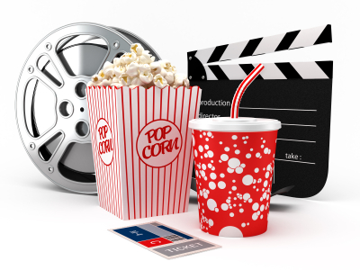

In this project focused on *Collective Intelligence Mining*, the group carried out 3 main goals:

1. To discover a succinct methodology for mining Amazon movie reviews.
2. To best display the results and findings of this mining.
3. To produce something others would also find useful and inventive

Thus, the group created an interactive Shiny app, where consumers can input what they like seeing/what they are interested in seeing, and not only get information on that move, but also similar titles to such!

# Exploratory Analysis

To direct how to carry out our algorithm, as well as take into account the vast amoutn of psycology that occurs with movie watching preferences, we did both an exploratory analysis on the movie industry, as well as the data set provided.

## General Background

When looking at current research available for movie watching habits, Google and Millward Brown Digital teamed up to carry out a very indepth study of people and their movie watching habits. **What struck us the most and influenced our decisions** moving forward were the following two things:

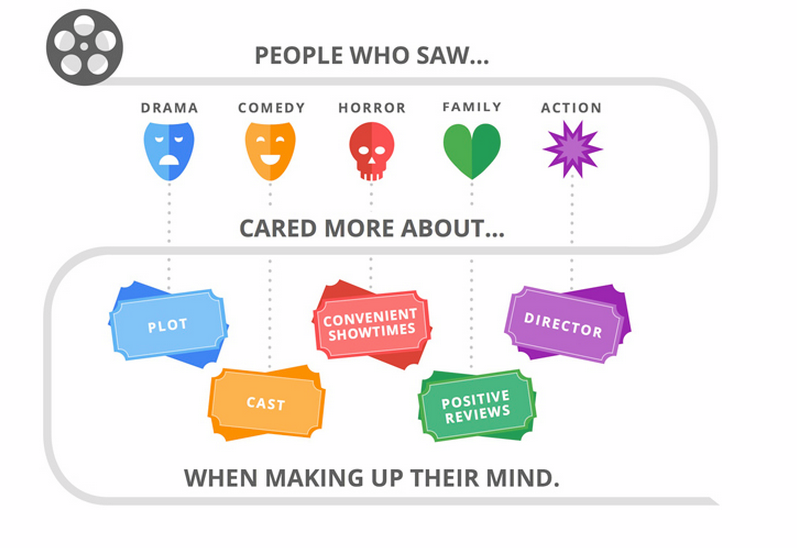

Taking these into account, we had ready information for plot/genre, as well as review score, two core factors that certain groups of movie watchers deemed important.

Additionally, the following statistic very much influenced how we moved forward: **70% of moviegoers don’t actually choose the movie the’ll see until they’re at the teater**

This is very applicable in propelling us to provide a movie reccommendation app, which would help both movie-goers in theaters (becuase you can rate movies on Amazon through pre-order dvds after people saw it in theater), and people at home.

# Setting Up The Environment: Introducing The Data

## Packages Used

The following packages were used in our project

```r
library(dplyr)
library(XML)
library(stringr)
library(tm)
library(seqinr)
library(bitops)
library(RCurl)
library(digest)
library(data.table)
```

## Data Cleaning Overview

1. Import all data from SNAP
2. Used the Amazon API to pull all the movie data
3. Preprocessing
- XML Parsing of desired info (ie: review score)
- Removing of undesired info (ie: price)
- Also adding in director and cast name
4. Cleaning and Subsetting
- Removed movies with review score of 0 for our algorithm -Kept this information for our exploratory analysis

## Amazon API

[figure not shown]

We used the Amazon API to pull information about the reviews and movies based on the SNAP-provided product and review ID’s.

We used the API only on the movies that had at least 1 review, which is roughly 1/4 of the provided data.

The cap for Amazon was at 3,600 calls an hour, so this took us about 13 hours to run the subsetted data.

## XML Parsing

The XML parsing was our main source of preprocessing. This “separated” out the information we wanted on each of the movies, and formatted it in a way we could manipulate in R. We also removed factors and information that we would not be using in our algorithm or analysis.